# MECH60017 STATISTICS EXERCISE SHEET 1

Dylan Chua

October 2024

A Geiger counter was used to record the number of alpha particles emitted by a radioactive material in 1 minute intervals and the results are displayed below. You will need to use this dataset for questions 1 and 2.

| 15 | 25 | 22 | 31 | 25 | 19 | 8 | 24 | 44 | 30 |
| --- | --- | --- | --- | --- | --- | --- | --- | --- | --- |
| 34 | 12 | 7 | 33 | 19 | 20 | 19 | 42 | 38 | 27 |

```r
geiger <- c(
  15, 25, 22, 31, 25, 19, 8, 24, 44, 30,
  34, 12, 7, 33, 19, 20, 19, 42, 38, 27
)
```

## Q1

## Construct a suitable histogram plot for the Geiger counter data.

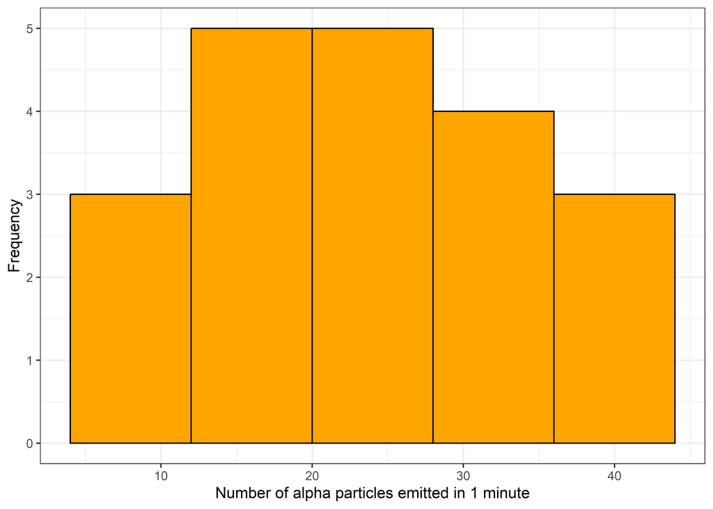

```r
library(ggplot2)

ggplot() +
  aes(x = geiger) +
  geom_histogram(binwidth = 8, fill = "orange", color = "black") +
  labs(x = "Number of alpha particles emitted in 1 minute", y = "Frequency") +
  theme_bw()
```

## Q2

Determine the sample mean, the sample variance, the median and the mode of the Geiger counter data. —

```r
# sample mean
mean(geiger)
```

```
## [1] 24.7
```

```r
# sample variance
var(geiger)
```

```
## [1] 108.0105
```

```r
# median
median(geiger)
```

```
## [1] 24.5
```

```r
# mode
modes <- function(x) {
  ux <- unique(x)
  tab <- tabulate(match(x, ux))
  ux[tab == max(tab)]
}
modes(geiger)
```

```
## [1] 19
```

## Q3

A random sample of 60 observations is such that $\sum_i x_i = 377$ and $\sum_i x_i^2 = 2377$. Starting from the definition of the sample variance:
$$s^2 = \frac{1}{n-1} \sum_{i=1}^n (x_i - \bar{x})^2$$
where $\bar{x}$ is the sample mean.

Show that the variance of the sample can be equivalently written as:
$$s^2 = \frac{1}{n-1} \left[ \left(\sum_{i=1}^n x_i^2 \right) - n
\bar{x}^2 \right]$$

## Hence, find the sample mean and standard deviation of this dataset.

**Solution:**

$$s^2 = \frac{1}{n-1} \sum_{i=1}^n (x_i - \bar{x})^2 \\
= \frac{1}{n-1} \sum_{i=1}^n (x_i^2 - 2x_i\bar{x} + \bar{x}^2) \\
= \frac{1}{n-1} \left[ \left(\sum_{i=1}^n x_i^2 \right) - 2\bar{x}
\left(\sum_{i=1}^n x_i \right) + n\bar{x}^2 \right] \\
= \frac{1}{n-1} \left[ \left(\sum_{i=1}^n x_i^2 \right) -
2n\bar{x}^2 + n\bar{x}^2 \right] \\
= \frac{1}{n-1} \left[ \left(\sum_{i=1}^n x_i^2 \right) -
n\bar{x}^2 \right]$$

```r
# sample size
n <- 60
# sum of observations
sum_x <- 377
# sum of squares of observations
sum_x2 <- 2377

# sample mean
sample_mean <- sum_x / n
sample_mean
```

```
## [1] 6.283333
```

```r
# standard deviation
sample_sd <- sqrt((sum_x2 - n * sample_mean^2) / (n - 1))
sample_sd
```

```
## [1] 0.3724252
```

## Q4

A frequency table for student performances is as follows:

| Class | Dash list | Frequency | Proportion (%) |
| --- | --- | --- | --- |
| 19-20 | // | 2 | 3.51 |
| 20-21 | / | 1 | 1.75 |
| 21-22 | ///// //// | 9 | 15.79 |
| 22-23 | ///// ///// ///// // | 17 | 29.82 |
| 23-24 | ///// ///// / | 11 | 19.30 |
| 24-25 | ///// // | 7 | 12.28 |
| 25-26 | ///// | 5 | 8.77 |
| 26-27 | / | 1 | 1.75 |
| 27-28 | /// | 3 | 5.26 |
| 28-29 | / | 1 | 1.75 |
| **Sum** |  | 57 | 99.98 |

```r
# class intervals
class_intervals <- c(19, 20, 21, 22, 23, 24, 25, 26, 27, 28)
# frequencies
frequencies <- c(2, 1, 9, 17, 11, 7, 5, 1, 3, 1)
# number of observations
n <- sum(frequencies)
```

1. Suppose we want to estimate the sample mean of this dataset by assuming that any point in the 19-20 range is taken to have value 19.5, any point in the 20-21 range has value 20.5, etc. Using this approach estimate the sample mean and variance of the strength dataset.

```r
# midpoints of class intervals
classes <- class_intervals + 0.5
classes
```

```
##  [1] 19.5 20.5 21.5 22.5 23.5 24.5 25.5 26.5 27.5 28.5
```

```r
# sample mean
mean <- sum(classes * frequencies) / n
mean
```

```
## [1] 23.34211
```

```r
# sample variance
variance <- sum((classes - mean)^2 * frequencies) / (n - 1)
variance
```

```
## [1] 3.599624
```

2. Estimate the minimum and maximum values of the sample mean.

```r
# minimum value of sample mean
classes <- class_intervals
min_mean <- sum(classes * frequencies) / n
min_mean
```

```
## [1] 22.84211
```

```r
# maximum value of sample mean
classes <- class_intervals + 1
max_mean <- sum(classes * frequencies) / n
max_mean
```

```
## [1] 23.84211
```

which makes sense since we are shifting the class values by $\pm 0.5$ for all observations, hence the minimum and maximum values of the sample mean will be shifted by $\pm 0.5$ as well.